# Modern maps with sf & projections

The legacy `maps` polygons are an unprojected plate carrée: they badly distort area and split Russia, Fiji and New Zealand across the antimeridian. The `sf` backend fixes all of this: real projections, equal-area options, and an antimeridian-safe pipeline. These features require the optional `sf` and `rnaturalearth` packages.

```r
install.packages(c("sf", "rnaturalearth", "rnaturalearthdata"))
```

## An equal-area, projected choropleth

```r
world_data(2020, c(gdp = "NY.GDP.PCAP.KD"), geometry = "sf") |>
  world_map(gdp, style = "quantile", projection = "equal_earth",
            title = "GDP per capita (Equal Earth projection)")
```

`world_map()` auto-detects the `sf` backend and applies the projection through `ggplot2::coord_sf()`. Available projections are `"equal_earth"` (the default: equal-area and good-looking), `"robinson"`, `"mollweide"`, `"natural_earth"`, `"plate_carree"`, `"mercator"`, `"winkel_tripel"`, `"eckert4"`, `"gall_peters"`, `"orthographic"`, `"azimuthal_equal_area"`, `"north_polar"` and `"south_polar"`.

`projection_info()` says what each one preserves, so you do not have to remember:

```r
projection_info()[, c("projection", "property", "equal_area")]
```

```
#> # A tibble: 13 × 3
#>    projection           property    equal_area
#>    <chr>                <chr>       <lgl>
#>  1 equal_earth          equal-area  TRUE
#>  2 robinson             compromise  FALSE
#>  3 mollweide            equal-area  TRUE
#>  4 natural_earth        compromise  FALSE
#>  5 plate_carree         equidistant FALSE
#>  6 mercator             conformal   FALSE
#>  7 winkel_tripel        compromise  FALSE
#>  8 eckert4              equal-area  TRUE
#>  9 gall_peters          equal-area  TRUE
#> 10 orthographic         perspective FALSE
#> 11 azimuthal_equal_area equal-area  TRUE
#> 12 north_polar          equal-area  TRUE
#> 13 south_polar          equal-area  TRUE
```

For a choropleth the equal-area ones are the honest choice, because the reader reads coloured area as quantity. `projection_compare()` draws your own data under several at once and `tissot_map()` shows the distortion directly (see the *Honest maps* vignette).

## The world as a globe

`globe_map()` draws an orthographic globe centred on `lon`/`lat`. The default `"sf"` backend gives the cleanest limb; the `"polygon"` backend below needs only `maps` + `mapproj` (no `sf`):

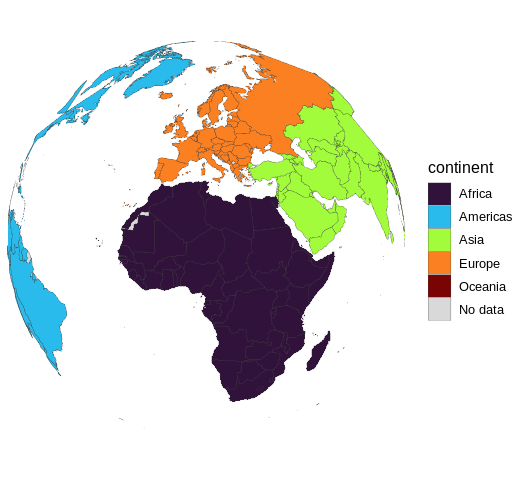

```r
globe_map(world_snapshot$countries, continent, backend = "polygon",
          style = "categorical", lon = 10, lat = 20)
```

```r
# With the sf backend (smoother limb, real great circles):
world_data(2020, geometry = "sf") |>
  globe_map(gdp_per_capita, lon = 10, lat = 30)
```

`spin_globe()` turns that into a rotating animation: one `globe_map()` frame per central longitude, assembled into a looping GIF with `gifski` (or `magick`):

```r
spin_globe(world_snapshot$countries, continent, backend = "polygon",
           style = "categorical", n_frames = 60)
```

## Just the canvas

`world_geometry()` returns projected, region-subset, antimeridian-safe geometry without any data: country polygons, label-ready centroids, coastlines, a graticule or an ocean rectangle:

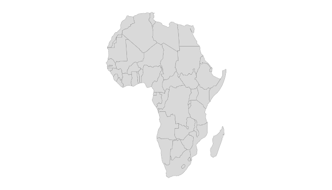

```r
africa <- world_geometry("countries", geometry = "sf", region = "Africa",
                         projection = "equal_earth")
ggplot(africa) +
  geom_sf(fill = "grey85", colour = "grey40", linewidth = 0.1) +
  theme_world_map()
```

## Recentring and the antimeridian

A Pacific-centred world is one argument away; the `sf` pipeline runs `sf::st_break_antimeridian()` before projecting, so nothing streaks across the frame:

```r
world_geometry("countries", geometry = "sf", recenter = 150)
```

## Region subsetting

`region` accepts a continent, a group name (`"EU"`, `"OECD"`, …), a vector of `iso3c` codes, or a bounding box `c(xmin, ymin, xmax, ymax)`. Pair it with a `projection` suited to the subset (e.g. `"azimuthal_equal_area"` for a single continent, the polar projections for the Arctic) so the crop stays area-honest.

A box is the one form that clips the shapes themselves, which is what you want for a region that is neither a continent nor a group, the Mediterranean basin, say. Use the `sf` backend for it: that clip is a real `sf::st_crop()`, whereas the polygon backend can only drop the vertices outside the box and warns that a country crossing the edge comes back with an approximate outline.

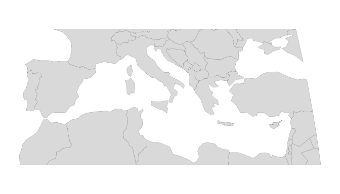

```r
med <- world_geometry("countries", geometry = "sf",
                      region = c(-10, 30, 40, 48), projection = "equal_earth")
ggplot(med) +
  geom_sf(fill = "grey85", colour = "grey40", linewidth = 0.1) +
  theme_world_map()
```

## Simplifying for the web

High-resolution geometry can be thinned for fast plotting with `simplify_geometry()` (which uses `rmapshaper` when available). `scale = "medium"` is the 50m Natural Earth data; `"large"` is 10m and additionally needs the `rnaturalearthhires` package, which is not on CRAN.

```r
world_geometry(geometry = "sf", scale = "medium") |>
  simplify_geometry(keep = 0.1)
```